# Report

Author

Miguel Angel Donado Fernandez

Published

June 20, 2026

**RQ2:** Analyze whether reducing the memory level of agents prevents the BM model from converging towards a DUE state

Convergence is measured via three R-gap variants computed by the `DUE_convergence` package: aggregated R-gap (overall convergence level), refined R-gap by departure interval (temporal heterogeneity), and OD-specific R-gap (spatial heterogeneity). BM is compared against `duaIterate` — SUMO’s built-in DUE solver — as a sanity-check baseline.

On this research question only the aggregated R-gap will be considered.

**The plots to answer this question will be:**

1. Aggregated R-gap for different memory levels across episodes (representative learning dynamics)
2. Sensitivity analysis
3. Variability across seeds

For more details, check the research questions document.

```r
# To make sure r virtual environment is loaded when executing this script from python
library(renv)
renv::load()
```

```
- The project is out-of-sync -- use `renv::status()` for details.
```

```r
library(tidyverse)
library(arrow)
library(ggh4x)
```

```r
library(here)

# Load custom theme
source(file = here("r","shared","theme.R"))

# Make it global theme (every plot automatically uses it)
theme_set(theme_thesis())

# Builds the congestion_regime factor from whatever n_agents values are
# present in the data, instead of hardcoding levels/labels per plot.
congestion_regime_tiers <- c("Near free-flow", "Moderate", "High")

make_congestion_regime <- function(n_agents) {
  levels_sorted <- sort(unique(n_agents))

  if (length(congestion_regime_tiers) != length(levels_sorted)) {
    stop("The number of congestion regime tiers must equal the number of unique agent counts.")
  }

  factor(
    n_agents,
    levels = levels_sorted,
    labels = paste0(congestion_regime_tiers, " (", levels_sorted, ")"))
}
```

```r
# This function helps us to create reliable file paths
data_dir <- here("r","RQ2","data")

# Dynamic data import
# 1) list.files(): returns a vector with the file paths
# 2) set_names(): transforms it into a named vector, with names equal to the filename without extension. This functions are vectorized, thats why it works
# 3) map(): maps the function to every parquet file. It returns a list, where each element is a df
data <- list.files(data_dir, pattern="\\.parquet$", full.names = TRUE) |>
  (\(x) set_names(x, tools::file_path_sans_ext(basename(x))))() |>
  map(read_parquet)
```

```r
# Randomly select 3 seeds (seeded so the same 3 - and their colors - are
# picked every time this re-renders)
set.seed(123)
representative_seeds <- sample(unique(data$bm_rgap$seed), size = 3)

labels_seeds <- c("S1", "S2", "S3")

color_lines <- c(
  "1.0" = "#0072B2",  # blue
  "0.6" = "#E69F00",  # orange
  "0.2" = "#009E73"  # bluish green
)
```

```r
representative_memory_levels <- c("1.0","0.6","0.2")
representative_memory_levels_labels <- map_chr(representative_memory_levels, \(x) paste0("γ = ", x))

# Not aggregating mean +/- SD across seeds here: seeds finish training at very
# different episode counts (e.g. High regime: some stop by episode ~22, one
# runs to 129), so for a large share of each panel's episode range the "mean"
# would silently collapse to a single seed's raw value (SD undefined). Each
# seed's own trajectory is plotted instead - no cross-seed averaging, so no
# misleading shrinking-N problem.

rgap_df <- data$bm_rgap |>
  mutate(
    congestion_regime = make_congestion_regime(n_agents),
    ) |>
  filter(
    seed %in% representative_seeds
  ) |>
  mutate(
    seed_fct = factor(seed, levels = representative_seeds, labels = labels_seeds)
  ) |>
  filter(
    memory_level %in% representative_memory_levels
  ) |>
  mutate(
    memory_level_fct = factor(memory_level, levels = representative_memory_levels, labels = representative_memory_levels_labels)
  ) |>
  mutate(memory_level_fct = fct_rev(memory_level_fct))
```

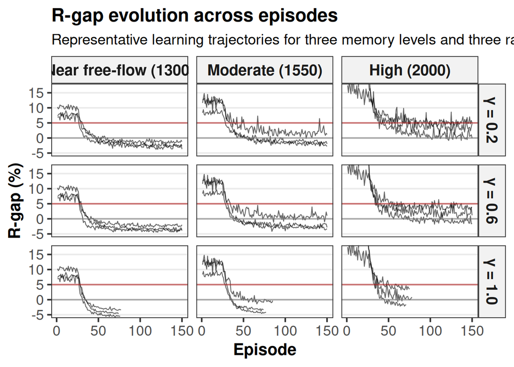

```r
upper_limit_y_axis <- quantile(rgap_df$rgap, probs = c(0.95))

ggplot(
  data = rgap_df,
  mapping = aes(x = episode, y = rgap, group = seed_fct)
) +
  geom_line(alpha = 0.6, linewidth = 0.4) +
  geom_hline(yintercept = 0, alpha = 0.6, linewidth = 0.7, color = "#7D7D7D") +
  geom_hline(yintercept = 5, alpha = 0.6, linewidth = 0.7, color = "#B22222") +
  facet_grid(memory_level_fct ~ congestion_regime) +
  labs(
    title = "R-gap evolution across episodes",
    subtitle = "Representative learning trajectories for three memory levels and three random seeds (BM)",
    x = "Episode",
    y = "R-gap (%)"
  ) +
coord_cartesian(ylim=c(-5,upper_limit_y_axis))
```

```r
ggsave(here("r","RQ2","figures","plot1_rgap_evolution_mem_seed.png"), width = 12, height = 6)
```

## Interpretation plot 1

- **Oscillatory behavior**: There is no evidence that decreasing memory produces oscillatory behavior.
- **DUE convergence**: All memory levels eventually approach similar low R-gap values (DUE state)
- **Behavioral convergence**: Higher memory levels lead to earlier stabilization of the agents policies.
- **Robustness across seeds**: Similar results are obtained across seeds.

Hence memory has relatively influence on the evolution of the aggregated R-gap, but it has a clear influence on behavioral convergence.

Intuitively, higher memory enables agents to accumulate knowledge over time, leading to earlier stabilization of route-choice policies. Lower memory places greater emphasis on recent experiences, causing policies to continue adapting for more episodes.

```r
sensitivity_df <- data$bm_rgap |>
  mutate(
    memory_level = as.numeric(memory_level),
    congestion_regime = make_congestion_regime(n_agents),
  ) |>
  select(-c(n_agents)) |>
  group_by(seed, congestion_regime, memory_level) |>
  slice_max(episode, n = 1) |>
  ungroup()

sensitivity_df_summary <- sensitivity_df |>
  group_by(memory_level, congestion_regime) |>
  summarise(
    median_rgap = median(rgap)
  ) |>
  ungroup()
```

```r
ggplot(
  data = sensitivity_df_summary,
  mapping = aes(
    x = memory_level,
    y = median_rgap
  )
) +
  geom_point() +
  geom_line(linewidth=1.4) +
  geom_line(
    data = sensitivity_df,
    mapping = aes(
      x = memory_level,
      y = rgap,
      group = seed
    ),
    linewidth = 0.45,
    alpha = 0.6,
    colour = "grey60"
  ) +
  facet_wrap(~congestion_regime) +
  labs(
    title = "Sensitivity of R-gap to memory level",
    subtitle = "Final-episode R-gap for five random seeds (thin lines) \nand their median (thick line)",
    x = "Memory level (γ)",
    y = "R-gap (%)"
  ) +
  scale_x_continuous(
    breaks = unique(sensitivity_df$memory_level)
  )

ggsave(here("r","RQ2","figures","plot2_sensitivity_analysis_memory.png"), width = 12, height = 6)
```

[output not shown]